# 309986255_302631361 final Exercise

dataset number: 21 - ‘Wong’

Lena Savin and Kobi Shapira

19.05.20

### Question 1:

### Using the helper function in R, identify the library where your dataset is stored. Install relevant libraries and call your dataset.

The sos library contains a function “findFn” which looks for datasets available in all available r packeges online, and opens the result in a default browser.

```r
library("sos")
findFn("Wong")
```

```
## found 287 matches;  retrieving 15 pages
## 2 3 4 5 6 7 8 9 10
## 11 12 13 14 15
## Downloaded 282 links in 125 packages.
```

```
## Ignoring template.
```

```r
library("carData")
data("Wong")
wong_data <- Wong
```

In the output here we found the relevant package for the “Wong” dataset: carData, installed the package, imported it and attached the dataset into a local variable “wong_data”.

### Question 2:

### a.What is the size of your dataset? What do the different variables mean? Write a short description (1 line) per variable. You may rely on any information you can find on the internet or use the helper function in R.

Adding a question mark before a dataset name or a function name reveals its datails.

```r
?Wong
```

```
## starting httpd help server ... done
```

note - there are patiants with more than one measurement.  
*The Wong dataset is observations are longitudinal data on recovery of IQ after comas of varying duration for 200 subjects. It has 331 row and 7 columns.*  
*1. id: patient id*  
*2. days: number of days after coma when iq was measured.*  
*3. duration: duration of the coma*  
*4. sex: sex of the patient (Female or Male)*  
*5. age: age of the patient.*  
*6. piq: mathematical IQ*  
*7. viq: verbal IQ*

### b. In one table, show the type, the minimum, the maximum, the mean and the median (when relevant) of each variable

```r
summary(wong_data)
```

```
##        id            days            duration         sex           age
##  Min.   : 405   Min.   :   13.0   Min.   :  0.0   Female: 71   Min.   : 6.513
##  1st Qu.:3808   1st Qu.:   59.0   1st Qu.:  1.0   Male  :260   1st Qu.:21.737
##  Median :5085   Median :  150.0   Median :  7.0                Median :26.877
##  Mean   :4735   Mean   :  481.9   Mean   : 14.3                Mean   :31.853
##  3rd Qu.:5712   3rd Qu.:  416.0   3rd Qu.: 16.0                3rd Qu.:40.923
##  Max.   :7548   Max.   :11628.0   Max.   :255.0                Max.   :80.033
##       piq              viq
##  Min.   : 50.00   Min.   : 64.00
##  1st Qu.: 77.00   1st Qu.: 85.00
##  Median : 87.00   Median : 94.00
##  Mean   : 87.56   Mean   : 94.96
##  3rd Qu.: 97.00   3rd Qu.:105.00
##  Max.   :133.00   Max.   :132.00
```

### c.In a plot, show the distributions of verbal IQ and mathematical IQ?

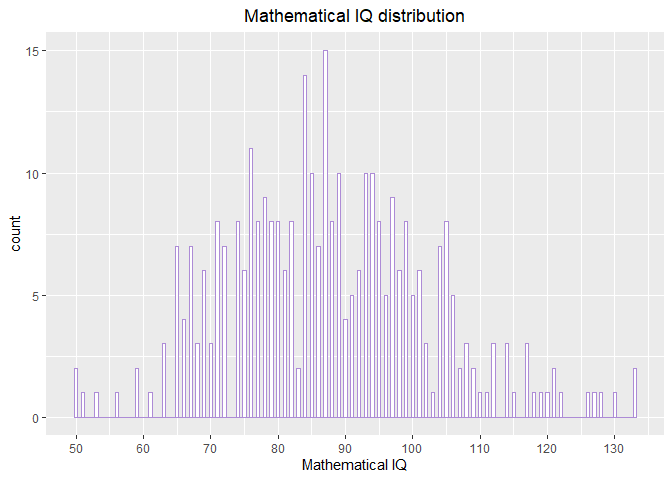

```r
library(ggplot2)
#Using bar plot to show piq's distribuation
piq_distribution <- ggplot(wong_data, mapping = aes(x=piq)) +
  geom_bar(binwidth = 0.5, color='#ad8bd6', fill='white') +
  labs(title="Mathematical IQ distribution", x= "Mathematical IQ") +
  theme(plot.title = element_text(hjust = 0.5)) +
  scale_x_continuous(breaks = seq(0,200, by=10))
piq_distribution
```

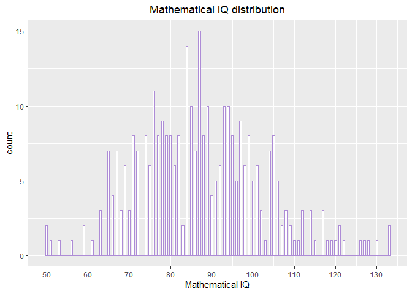

```r
#Using bar plot to show viq's distribuation
viq_distribution <- ggplot(wong_data, mapping = aes(x=viq, )) +
  geom_bar(binwidth = 0.5, color='#ad8bd6', fill='white') +
  labs(title="Verbal IQ distribution", x= "Verbal IQ") +
  theme(plot.title = element_text(hjust = 0.5)) +
  scale_x_continuous(breaks = seq(0,200, by=10))
piq_distribution
```

[output not shown]

### Question 3:

### a. On a plot, show the relation between verbal and mathematical IQ. Your plot should include relevant axis names, a title and a subtitle.

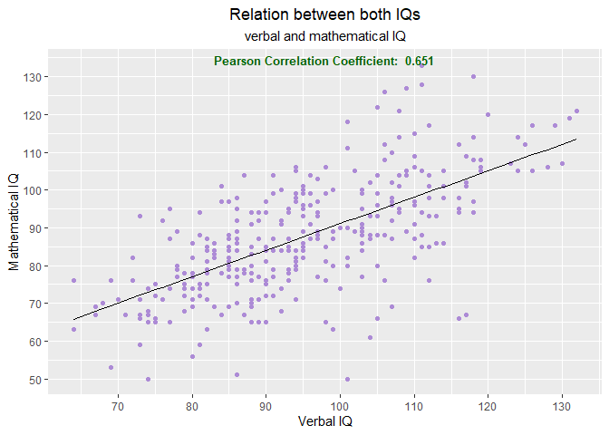

```r
mod1=lm(piq~viq, data=wong_data) # linear model

library(grid)
library(gridExtra)

grob = grobTree(textGrob(paste("Pearson Correlation Coefficient: ", round(cor(wong_data$piq, wong_data$viq), 4) ), x = 0.3, y = 0.97,
hjust = 0, gp = gpar(col = "darkgreen", fontsize = 10, fontface = "bold")))

wong_data$fitted<-fitted(mod1) # fitting the model to the data

raltion_piq_viq <- ggplot(wong_data, aes(x=viq, y=piq)) +
  geom_point(color='#ad8bd6') +
  geom_line(aes(y=fitted)) +
  labs(title="Relation between both IQs",
       subtitle = "verbal and mathematical IQ",
       x="Verbal IQ",  y= "Mathematical IQ") +
  annotation_custom(grob) +
  theme(plot.title = element_text(hjust = 0.5), #centering the title
        plot.subtitle = element_text(hjust=0.5)) + #centering the subtitle
  scale_x_continuous(breaks = seq(0,200, by=10)) + #adding ticks to x axis
  scale_y_continuous(breaks = seq(0,200, by=10))   #adding ticks to y axis
raltion_piq_viq
```

There is a positive correlation between viq and piq.

### b. Are verbal and mathematical IQs correlated? Which test do you perform to answer this question and why?

```r
t.test(x = wong_data$viq, y= wong_data$piq, paired = TRUE, alternative = "two.sided")
```

```
##
##  Paired t-test
##
## data:  wong_data$viq and wong_data$piq
## t = 11.02, df = 330, p-value < 2.2e-16
## alternative hypothesis: true difference in means is not equal to 0
## 95 percent confidence interval:
##  6.085463 8.730247
## sample estimates:
## mean of the differences
##                7.407855
```

### c. In a table, calculate the average total IQ (sum of two IQs) per gender

```r
library(dplyr)
wong_data$totalIQ <-(wong_data$viq + wong_data$piq)/2 #calculating total IQ per person
wong_by_geander <- wong_data %>% select(sex, totalIQ) %>% group_by(sex) %>%
  summarise(meanIQ= mean(totalIQ)) #grouping by gender and summerising the result
wong_by_geander
```

```
## # A tibble: 2 x 2
##   sex    meanIQ
##   <fct>   <dbl>
## 1 Female   91.8
## 2 Male     91.1
```

### d. Using a statistical method of your choice, is there a significant difference in IQ between genders? What test do you choose to answer this question and why?

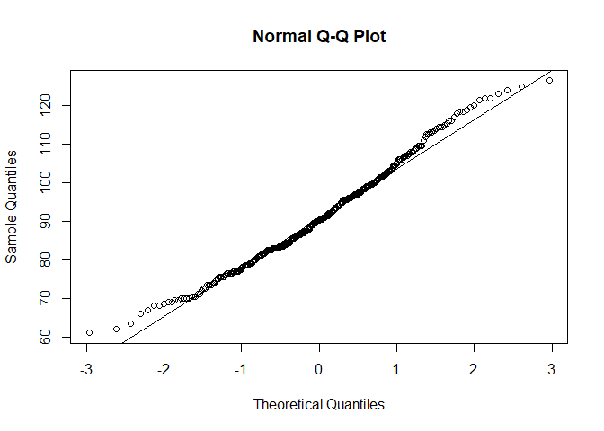

```r
# checking if the total Iq is distributed normaly
qqnorm(wong_data$totalIQ)
qqline(wong_data$totalIQ)
```

Unpaired two-samples t-test is used to compare the mean of two independent group, and the total iq is also distributed normaly. Also the two groups are not related, therefore we can use the unpaired t test.

```r
male_iq <- select(filter(wong_data, sex=="Male"), totalIQ)
female_iq <- select(filter(wong_data, sex=="Female"), totalIQ)
t.test(x=male_iq, y=female_iq, var.equal = T,
              alternative = "two.sided")
```

```
##
##  Two Sample t-test
##
## data:  male_iq and female_iq
## t = -0.36359, df = 329, p-value = 0.7164
## alternative hypothesis: true difference in means is not equal to 0
## 95 percent confidence interval:
##  -4.144034  2.851130
## sample estimates:
## mean of x mean of y
##  91.12115  91.76761
```

As we can see in the results there is no significant diffarence between the two means - the p-value is higher than the significance level alpha = 0.05.

### e. Show your results to question 3.d. with a plot.

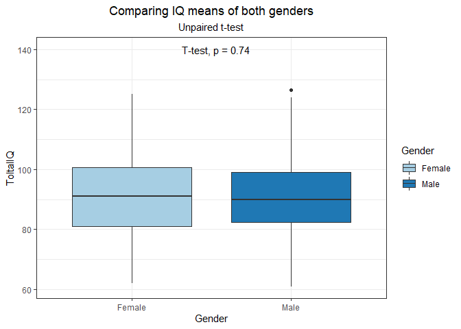

```r
library(ggpubr)
gender_diff <- ggplot(wong_data, aes(x=as.factor(sex), y=totalIQ, fill = as.factor(sex))) +
  labs(title= "Comparing IQ means of both genders",
       subtitle = "Unpaired t-test",
       x="Gender", y= "ToltalIQ", fill="Gender") + theme_bw() +
  scale_fill_brewer(palette = "Paired") +
  theme(plot.title = element_text(hjust = 0.5),
        plot.subtitle = element_text(hjust=0.5)) +
  geom_boxplot() +
  stat_compare_means(method = "t.test",
                     label.x = 1.4,
                     label.y = 140)
gender_diff
```

### Question 4: Using all the variables at your disposition, build the best model possible to explain a patient’s IQ after a coma. You can try as many models as you wish. In your code, show all the formulas you have tested but only show the results of the best model. Explain your method.

Looking at the data, and the results so far, we think that duration of the comma is the variable that will best explain the iq, but the days after the comma are also valuble.  
First, we need to make sure the other variables are not making “noise”.  
We saw that there is no signifaicant difarence in iq between genders, now, we checked the age.

```r
mod1=lm(totalIQ~age, data=wong_data) # linear model
summary(mod1)
```

```
##
## Call:
## lm(formula = totalIQ ~ age, data = wong_data)
##
## Residuals:
##     Min      1Q  Median      3Q     Max
## -29.852  -9.193  -0.909   8.426  34.827
##
## Coefficients:
##             Estimate Std. Error t value Pr(>|t|)
## (Intercept) 89.24814    1.82696  48.851   <2e-16 ***
## age          0.06315    0.05260   1.201    0.231
## ---
## Signif. codes:  0 '***' 0.001 '**' 0.01 '*' 0.05 '.' 0.1 ' ' 1
##
## Residual standard error: 13.25 on 329 degrees of freedom
## Multiple R-squared:  0.004363,   Adjusted R-squared:  0.001336
## F-statistic: 1.442 on 1 and 329 DF,  p-value: 0.2308
```

As expected the p-value is not significant and therefore there is no relation.

Now we can look at the distribution of days and duration:

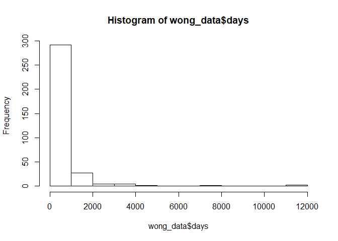

```r
days_hist <- hist(wong_data$days)
```

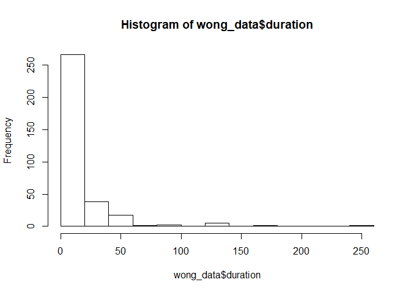

```r
duration_hist <- hist(wong_data$duration)
```

Since there is a very small portion of values above 60 duration days and above 200 days before the test, in order to see the distribution of the majoraty of the values we excluded them and saved the new dataset in “wong_data_z” variable, plotted in a histogram again.

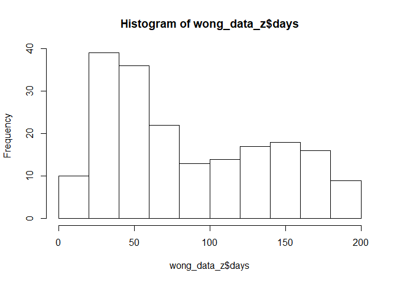

```r
wong_data_z <- wong_data %>% filter(duration < 60, days < 200)

#look at the distribution of days and duration after reduction.
hist_days_new <- hist(wong_data_z$days)
```

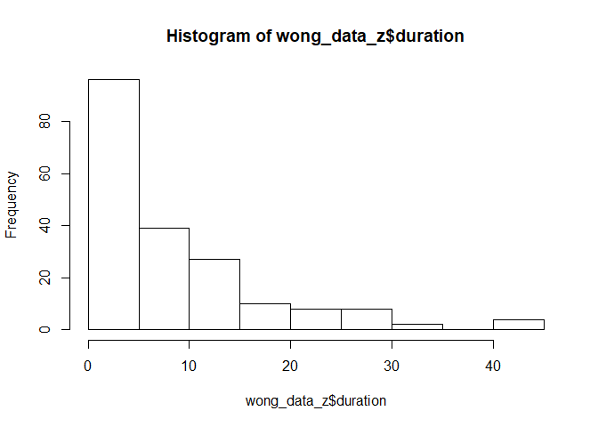

```r
hist_duration_new <- hist(wong_data_z$duration)
```

Now we can see the distribution better. These values are unusual, therefore they may influence on the model, for this reason we continue with the filtered dataset.

```r
library("lme4")
iq_lm1 <- lm(totalIQ ~ duration, data = wong_data_z)
iq_lm2 <- lm(totalIQ ~ duration + days, data = wong_data_z)
iq_lmer1 <- lm(totalIQ ~ duration + (1 | days), data = wong_data_z)
iq_lm3 <- lm(totalIQ ~ duration*days, data = wong_data_z)
summary(iq_lm2) #best
```

```
##
## Call:
## lm(formula = totalIQ ~ duration + days, data = wong_data_z)
##
## Residuals:
##     Min      1Q  Median      3Q     Max
## -32.366  -7.894  -0.689   7.530  28.905
##
## Coefficients:
##             Estimate Std. Error t value Pr(>|t|)
## (Intercept) 89.43517    1.85339  48.255  < 2e-16 ***
## duration    -0.38735    0.09858  -3.929 0.000119 ***
## days         0.05143    0.01728   2.976 0.003298 **
## ---
## Signif. codes:  0 '***' 0.001 '**' 0.01 '*' 0.05 '.' 0.1 ' ' 1
##
## Residual standard error: 12.71 on 191 degrees of freedom
## Multiple R-squared:  0.1011, Adjusted R-squared:  0.0917
## F-statistic: 10.74 on 2 and 191 DF,  p-value: 3.791e-05
```

### Question 5: Create a model to explain how much time it takes for a patient to recover based on the desired IQ level and the duration of the coma.

```r
model_days_to_recover <- lm(days ~ duration + totalIQ, data=wong_data_z)
summary(model_days_to_recover)
```

```
##
## Call:
## lm(formula = days ~ duration + totalIQ, data = wong_data_z)
##
## Residuals:
##    Min     1Q Median     3Q    Max
## -84.01 -45.50 -16.91  42.79 110.63
##
## Coefficients:
##             Estimate Std. Error t value Pr(>|t|)
## (Intercept)  -0.7416    27.5519  -0.027  0.97855
## duration      1.0833     0.4121   2.629  0.00927 **
## totalIQ       0.8616     0.2895   2.976  0.00330 **
## ---
## Signif. codes:  0 '***' 0.001 '**' 0.01 '*' 0.05 '.' 0.1 ' ' 1
##
## Residual standard error: 52.04 on 191 degrees of freedom
## Multiple R-squared:  0.06238,    Adjusted R-squared:  0.05256
## F-statistic: 6.353 on 2 and 191 DF,  p-value: 0.002131
```

Ploting the model to see it visualy.

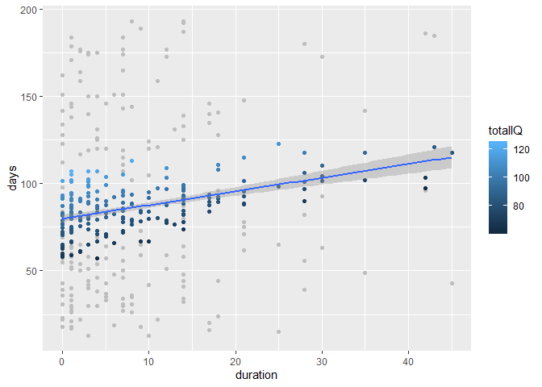

```r
wong_data_z$fitted<-fitted(model_days_to_recover) #fit
ggplot(wong_data_z, aes(x=duration ,y=days,color=totalIQ)) +
  geom_point(color="grey") + #color original points in grey
  geom_point(aes(y=fitted)) +
  geom_smooth(aes(y=fitted), method = "lm")
```

This model is significant for the totalIq and coma duration therefore we can use this model to predict how many days is needed before measuring IQ to get the desired result.

### 6. Considering Marc had a global IQ of 95 before his accident, how much time would it take to recover after his comas if he wakes up after:

### a. One week of coma.

```r
days_to_recover_week_coma <- predict(model_days_to_recover, data.frame(totalIQ=95 , duration=c(0,7)))
days_to_recover_week_coma
```

```
##        1        2
## 81.11121 88.69398
```

after a one week coma, it would take about 89 days.

### b. Two weeks of coma.

```r
days_to_recover_twoWeek_coma <- predict(model_days_to_recover, data.frame(totalIQ=95 , duration=c(0,14)))
days_to_recover_twoWeek_coma
```

```
##        1        2
## 81.11121 96.27675
```

After a two week coma, it would take about 96 days.  
As expected- the longer the coma - the longer time to recover.

### c. Calculate the speed of IQ recovery in each case (Gain of IQ points / coma duration).

Predicting the iq with the duration and days (predicted from initial IQ)

```r
iq_after_coma_week <- predict(iq_lm2, data.frame(duration=7, days=89))
gain_Of_iq_points_week = (95-iq_after_coma_week)/7
gain_Of_iq_points_week
```

```
##         1
## 0.5284111
```

One week - 0.53 IQ points a day.

```r
iq_after_coma_two_weeks <-predict(iq_lm2, data.frame(duration=14, days=96))
gain_Of_iq_points_two_weeks = (95 - iq_after_coma_two_weeks)/14
gain_Of_iq_points_two_weeks
```

```
##         1
## 0.4321625
```

Two weeks - 0.43 IQ points a day.  
This also supports our outcome and hipothesis- The longer the coma, the longer it will take to recover.